# KNN regression experiments

### Prepare data for machine learning

We will use KNN regression to predict the price of a house from its features, such as size, age and location.

We use a subset of the data set for our training and test data. Note that we keep an unscaled version of the data for one of the experiments we will run.

```python
# for repeatability
np.random.seed(42)
```

```python
# select the predictor variables and target variables to be used with regression
predictors = ['longitude','latitude','housing_median_age','total_rooms', 'total_bedrooms', 'population', 'households', 'median_income']
#dropping categortical features, such as ocean_proximity, including spatial ones such as long/lat.
target = 'median_house_value'
X = df[predictors].values
y = df[target].values
```

```python
# KNN can be slow, so get a random sample of the full data set
indexes = np.random.choice(y.size, size=10000)
X_mini = X[indexes]
y_mini = y[indexes]
```

```python
# Split the data into training and test sets, and scale
scaler = StandardScaler()

# unscaled version (note that scaling is only used on predictor variables)
X_train_raw, X_test_raw, y_train, y_test = train_test_split(X_mini, y_mini, test_size=0.30, random_state=42)

# scaled version
X_train = scaler.fit_transform(X_train_raw)
X_test = scaler.transform(X_test_raw)
```

```python
# sanity check
print(X_train.shape)
print(X_train[:3])
```

```
(7000, 8)
[[ 1.22783551 -1.3492796   0.34639424 -0.16627017  0.11697691 -0.15874461
   0.18687025 -0.74984935]
 [ 0.62095726 -0.82169566  0.58720859 -0.11584049 -0.22077651 -0.0770853
  -0.14171346  1.12877289]
 [-1.16983102  0.7563873  -0.45632025 -0.32112946  0.02736886 -0.37395092
  -0.04890738 -0.10303138]]
```

## Baseline performance

*For regression problems, our baseline is the "blind" prediction that is just the average value of the target variable. The blind prediction must be calculated using the training data. Calculate and print the test set root mean squared error (test RMSE) using this blind prediction. I have provided a function you can use for RMSE.*

```python
def rmse(predicted, actual):
    return np.sqrt(((predicted - actual)**2).mean())
```

```python
baseline_predictions = np.mean(y_train)
test_rmse_baseline = rmse(baseline_predictions, y_test)
print("Baseline Test RMSE: ", test_rmse_baseline)
```

```
Baseline Test RMSE:  112909.28341439406
```

## Performance with default hyperparameters

*Using the training set, train a KNN regression model using the ScikitLearn KNeighborsRegressor, and report on the test RMSE. The test RMSE is the RMSE computed using the test data set.*

*When using the KNN algorithm, use algorithm='brute' to get the basic KNN algorithm.*

```python
regr = KNeighborsRegressor(algorithm='brute')
regr.fit(X_train, y_train)
predictions = regr.predict(X_test)
test_rmse_default = rmse(predictions, y_test)
print("Test RMSE with default hyperparameters: ", test_rmse_default)
```

```
Test RMSE with default hyperparameters:  62448.852862157735
```

## Impact of K

```python
def get_train_test_rmse(regr, X_train, X_test, y_train, y_test):
    regr.fit(X_train, y_train)
    train_rmse = rmse(regr.predict(X_train), y_train)
    test_rmse = rmse(regr.predict(X_test), y_test)
    return train_rmse, test_rmse
```

```python
n = 30
test_rmse = []
train_rmse = []
ks = np.arange(1, n+1, 2)
for k in ks:
    print(k, ' ', end='')
    regr = KNeighborsRegressor(n_neighbors=k, algorithm='brute')
    rmse_tr, rmse_te = get_train_test_rmse(regr, X_train, X_test, y_train, y_test)
    train_rmse.append(rmse_tr)
    test_rmse.append(rmse_te)
print('done')
```

```
1  3  5  7  9  11  13  15  17  19  21  23  25  27  29  done
```

```python
# sanity check
print('Test RMSE when k = 3: {:0.1f}'.format(np.array(test_rmse)[ks==3][0]))
```

```
Test RMSE when k = 3: 64167.1
```

*Using the training and test RMSE values you got for each value of k, find the k associated with the lowest test RMSE value. Print this k value and the associated lowest test RMSE value. In other words, if you found that k=11 gave the lowest test RMSE, then print the value 11 and the test RMSE value obtained when k=11.*

```python
def get_best(ks, rmse):
    min_index = np.argmin(rmse)
    return ks[min_index], rmse[min_index]

best_k, best_rmse = get_best(ks, test_rmse)
print('best k = {}, best test RMSE: {:0.1f}'.format(best_k, best_rmse))
```

```
best k = 7, best test RMSE: 62421.5
```

*Plot the test and training RMSE as a function of k, for all the k values you tried.*

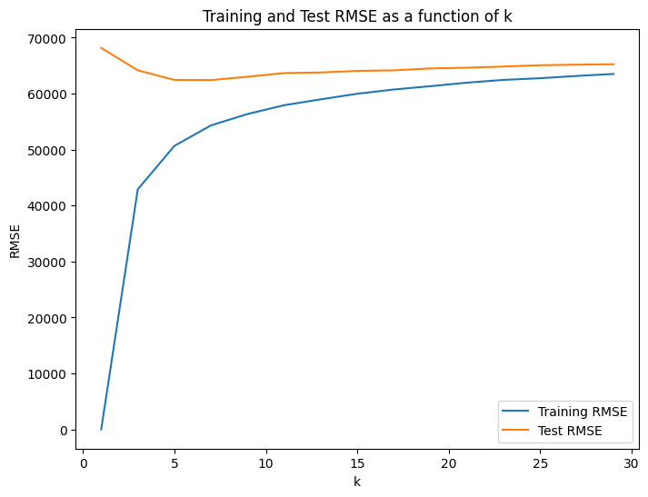

```python
plt.plot(ks, train_rmse, label='Training RMSE')
plt.plot(ks, test_rmse, label='Test RMSE')
plt.xlabel('k')
plt.ylabel('RMSE')
plt.legend()
plt.title('Training and Test RMSE as a function of k')
plt.show()
```

### Comments

From the plot, we observe that the test RMSE initially decreases as k increases, indicating a reduction in overfitting. However, after a certain point, the test RMSE starts to increase, suggesting that the model begins to underfit. Therefore, selecting an optimal k value is crucial for achieving good performance.

## Impact of noise predictors

*The add_noise_predictor() method makes it easy to add a predictor variable of random values to X_train or X_test.*

```python
def add_noise_predictor(X):
    """ add a column of random values to 2D array X """
    noise = np.random.normal(size=(X.shape[0], 1))
    return np.hstack((X, noise))
```

```python
base_rmse = best_rmse
noise_predictors = 4
noise_rmse = []
for i in range(noise_predictors + 1):
    X_train_noisy = X_train
    X_test_noisy = X_test
    for _ in range(i):
        X_train_noisy = add_noise_predictor(X_train_noisy)
        X_test_noisy = add_noise_predictor(X_test_noisy)
    regr = KNeighborsRegressor(n_neighbors=10, algorithm='brute')
    rmse_tr, rmse_te = get_train_test_rmse(regr, X_train_noisy, X_test_noisy, y_train, y_test)
    noise_rmse.append(rmse_te)
```

*Plot the percent increase in test RMSE as a function of the number of noise predictors. The x axis will range from 0 to 4. The y axis will show a percent increase in test RMSE.*

*To compute percent increase in RMSE for n noise predictors, compute 100 * (rmse - base_rmse)/base_rmse, where base_rmse is the test RMSE with no noise predictors, and rmse is the test RMSE when n noise predictors have been added.*

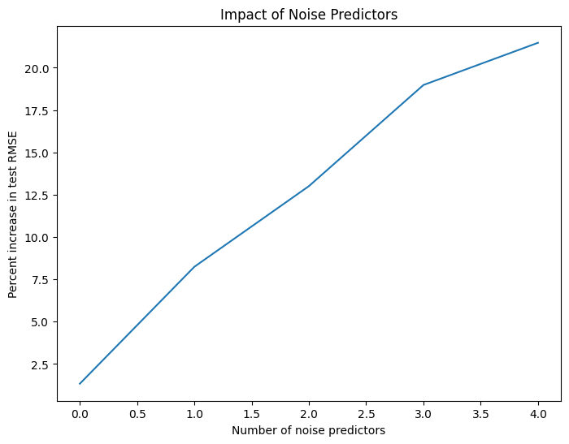

```python
percent_increase = [100 * (rmse - base_rmse) / base_rmse for rmse in noise_rmse]
plt.plot(range(noise_predictors + 1), percent_increase)
plt.xlabel('Number of noise predictors')
plt.ylabel('Percent increase in test RMSE')
plt.title('Impact of Noise Predictors')
plt.show()
```

### Comments

Adding noise predictors generally increases the test RMSE, confirming that useless predictors degrade the performance of KNN regression. This increase in error supports the recommendation to avoid including irrelevant features in the model.

## Impact of scaling

```python
X_train_unscaled, X_test_unscaled, y_train, y_test = train_test_split(X_mini, y_mini, test_size=0.30, random_state=42)

n = 30
test_rmse_unscaled = []
train_rmse_unscaled = []
ks = np.arange(1, n+1, 2)
for k in ks:
    print(k, ' ', end='')
    regr = KNeighborsRegressor(n_neighbors=k, algorithm='brute')
    rmse_tr, rmse_te = get_train_test_rmse(regr, X_train_unscaled, X_test_unscaled, y_train, y_test)
    train_rmse_unscaled.append(rmse_tr)
    test_rmse_unscaled.append(rmse_te)
print('done')
```

```
1  3  5  7  9  11  13  15  17  19  21  23  25  27  29  done
```

*Print the best k and the test RMSE associated with the best k.*

```python
best_k_unscaled, best_rmse_unscaled = get_best(ks, test_rmse_unscaled)
print('best k = {}, best test RMSE with unscaled data: {:0.1f}'.format(best_k_unscaled, best_rmse_unscaled))
```

```
best k = 9, best test RMSE with unscaled data: 94057.4
```

*Plot training and test RMSE as a function of k. Your plot title should note the use of unscaled data.*

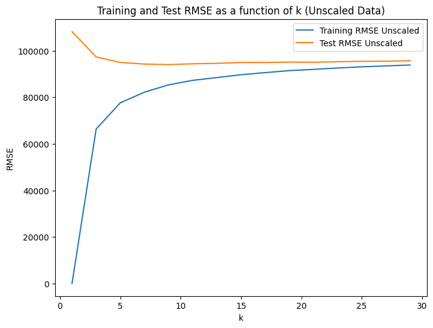

```python
plt.plot(ks, train_rmse_unscaled, label='Training RMSE Unscaled')
plt.plot(ks, test_rmse_unscaled, label='Test RMSE Unscaled')
plt.xlabel('k')
plt.ylabel('RMSE')
plt.legend()
plt.title('Training and Test RMSE as a function of k (Unscaled Data)')
plt.show()
```

### Comments

Using unscaled data results in higher RMSE values, both for training and test sets, compared to scaled data. This demonstrates the importance of scaling the features when using KNN, as KNN is sensitive to the scale of the input variables.

## Impact of algorithm

```python
algorithms = ['ball_tree', 'kd_tree', 'brute']
algorithm_rmse = []
for algo in algorithms:
    regr = KNeighborsRegressor(n_neighbors=10, algorithm=algo)
    rmse_tr, rmse_te = get_train_test_rmse(regr, X_train, X_test, y_train, y_test)
    algorithm_rmse.append(rmse_te)
```

*Print the name of the best algorith, and the test RMSE achieved with the best algorithm.*

```python
best_algo = algorithms[np.argmin(algorithm_rmse)]
best_algo_rmse = min(algorithm_rmse)
print('Best algorithm = {}, best test RMSE: {:0.1f}'.format(best_algo, best_algo_rmse))
```

```
Best algorithm = ball_tree, best test RMSE: 63254.8
```

*Plot the test RMSE for each of the three algorithms as a bar plot.*

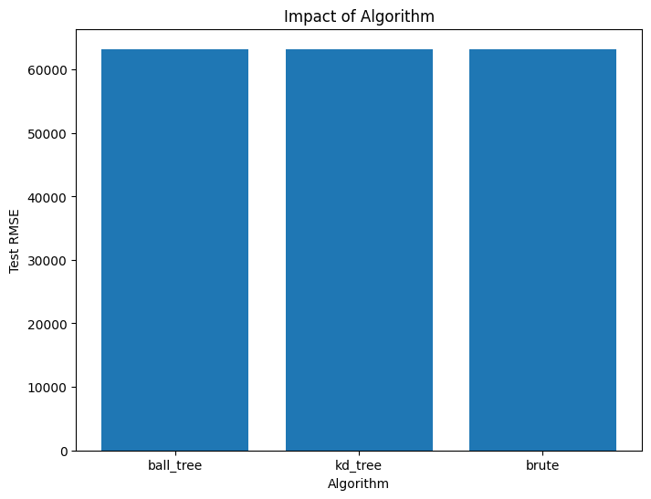

```python
plt.bar(algorithms, algorithm_rmse)
plt.xlabel('Algorithm')
plt.ylabel('Test RMSE')
plt.title('Impact of Algorithm')
plt.show()
```

## Impact of weighting

```python
weighting = ['uniform', 'distance']
weighting_rmse = []
for weight in weighting:
    regr = KNeighborsRegressor(n_neighbors=10, algorithm='brute', weights=weight)
    rmse_tr, rmse_te = get_train_test_rmse(regr, X_train, X_test, y_train, y_test)
    weighting_rmse.append(rmse_te)
```

*Print the weighting the gave the lowest test RMSE, and the test RMSE it achieved.*

```python
best_weight = weighting[np.argmin(weighting_rmse)]
best_weight_rmse = min(weighting_rmse)
print('Best weighting = {}, best test RMSE: {:0.1f}'.format(best_weight, best_weight_rmse))
```

```
Best weighting = distance, best test RMSE: 55817.1
```

*Create a bar plot showing the test RMSE for the uniform and distance weighting options.*

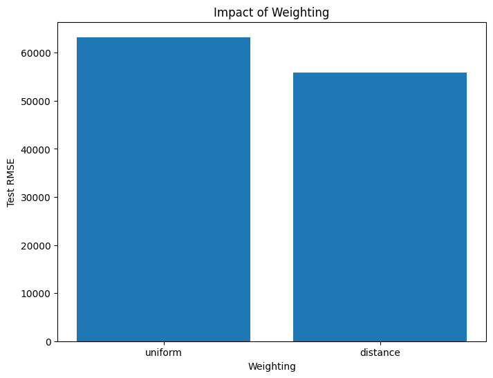

```python
plt.bar(weighting, weighting_rmse)
plt.xlabel('Weighting')
plt.ylabel('Test RMSE')
plt.title('Impact of Weighting')
plt.show()
```

### Comments

Using distance weighting results in a lower test RMSE compared to uniform weighting, indicating that giving more weight to closer neighbors improves the model's performance.

## Conclusions

From these experiments, we learned that the choice of k is crucial as it significantly impacts the model's performance. Including irrelevant predictors degrades the performance, reinforcing the need to select meaningful features. Scaling the features is essential for optimal performance, as KNN is sensitive to the scale of input variables. Additionally, different KNN algorithms can provide computational advantages without significantly compromising accuracy, and weighting closer neighbors more heavily generally improves performance.